# Supervised Learning: Regression Project 2 - Cars4U

### June 2022

## Section 1: Understanding the DataSet (Overview) - EDA

### Problem Definition

- Given data containing the "different attributes of used cars sold in different locations,"
  - derive insights from the data
  - predict the prices of used cars (linear Regression model)
  - communicate recommendations that will help the business

```python
import pandas as pd
import numpy as np
import matplotlib.pyplot as plt
import seaborn as sns

%matplotlib inline
# Removes the limit from the number of displayed columns and rows. ((code from video lecture FIFA notebook: video lecture)
pd.set_option('display.max_columns', None)
pd.set_option('display.max_rows', 200)
```

```python
#Read csv file
cars=pd.read_csv('used_cars_data.csv')
cars.head()
```

|  | S.No. | Name | Location | Year | Kilometers_Driven | Fuel_Type | Transmission | Owner_Type | Mileage | Engine | Power | Seats | New_Price | Price |
| --- | --- | --- | --- | --- | --- | --- | --- | --- | --- | --- | --- | --- | --- | --- |
| 0 | 0 | Maruti Wagon R LXI CNG | Mumbai | 2010 | 72000 | CNG | Manual | First | 26.6 km/kg | 998 CC | 58.16 bhp | 5.0 | 5.51 | 1.75 |
| 1 | 1 | Hyundai Creta 1.6 CRDi SX Option | Pune | 2015 | 41000 | Diesel | Manual | First | 19.67 kmpl | 1582 CC | 126.2 bhp | 5.0 | 16.06 | 12.50 |
| 2 | 2 | Honda Jazz V | Chennai | 2011 | 46000 | Petrol | Manual | First | 18.2 kmpl | 1199 CC | 88.7 bhp | 5.0 | 8.61 | 4.50 |
| 3 | 3 | Maruti Ertiga VDI | Chennai | 2012 | 87000 | Diesel | Manual | First | 20.77 kmpl | 1248 CC | 88.76 bhp | 7.0 | 11.27 | 6.00 |
| 4 | 4 | Audi A4 New 2.0 TDI Multitronic | Coimbatore | 2013 | 40670 | Diesel | Automatic | Second | 15.2 kmpl | 1968 CC | 140.8 bhp | 5.0 | 53.14 | 17.74 |

```python
# Display 10 random rows

np.random.seed(1)
cars.sample(n=10)
```

|  | S.No. | Name | Location | Year | Kilometers_Driven | Fuel_Type | Transmission | Owner_Type | Mileage | Engine | Power | Seats | New_Price | Price |
| --- | --- | --- | --- | --- | --- | --- | --- | --- | --- | --- | --- | --- | --- | --- |
| 2397 | 2397 | Ford EcoSport 1.5 Petrol Trend | Kolkata | 2016 | 21460 | Petrol | Manual | First | 17.0 kmpl | 1497 CC | 121.36 bhp | 5.0 | 9.47 | 6.00 |
| 3777 | 3777 | Maruti Wagon R VXI 1.2 | Kochi | 2015 | 49818 | Petrol | Manual | First | 21.5 kmpl | 1197 CC | 81.80 bhp | 5.0 | 5.44 | 4.11 |
| 4425 | 4425 | Ford Endeavour 4x2 XLT | Hyderabad | 2007 | 130000 | Diesel | Manual | First | 13.1 kmpl | 2499 CC | 141 bhp | 7.0 | 35.29 | 6.00 |
| 3661 | 3661 | Mercedes-Benz E-Class E250 CDI Avantgrade | Coimbatore | 2016 | 39753 | Diesel | Automatic | First | 13.0 kmpl | 2143 CC | 201.1 bhp | 5.0 | 86.97 | 35.28 |
| 4514 | 4514 | Hyundai Xcent 1.2 Kappa AT SX Option | Kochi | 2016 | 45560 | Petrol | Automatic | First | 16.9 kmpl | 1197 CC | 82 bhp | 5.0 | 8.23 | 6.34 |
| 599 | 599 | Toyota Innova Crysta 2.8 ZX AT | Coimbatore | 2019 | 40674 | Diesel | Automatic | First | 11.36 kmpl | 2755 CC | 171.5 bhp | 7.0 | 28.05 | 24.82 |
| 186 | 186 | Mercedes-Benz E-Class E250 CDI Avantgrade | Bangalore | 2014 | 37382 | Diesel | Automatic | First | 13.0 kmpl | 2143 CC | 201.1 bhp | 5.0 | 86.97 | 32.00 |
| 305 | 305 | Audi A6 2011-2015 2.0 TDI Premium Plus | Kochi | 2014 | 61726 | Diesel | Automatic | First | 17.68 kmpl | 1968 CC | 174.33 bhp | 5.0 | 67.10 | 20.77 |
| 4582 | 4582 | Hyundai i20 1.2 Magna | Kolkata | 2011 | 36000 | Petrol | Manual | First | 18.5 kmpl | 1197 CC | 80 bhp | 5.0 | 10.25 | 2.50 |
| 5434 | 5434 | Honda WR-V Edge Edition i-VTEC S | Kochi | 2019 | 13913 | Petrol | Manual | First | 17.5 kmpl | 1199 CC | 88.7 bhp | 5.0 | 9.36 | 8.20 |

```python
#Understand tha overall dataset structure and data types
cars.info()
```

```
<class 'pandas.core.frame.DataFrame'>
RangeIndex: 7253 entries, 0 to 7252
Data columns (total 14 columns):
 #   Column             Non-Null Count  Dtype
---  ------             --------------  -----
 0   S.No.              7253 non-null   int64
 1   Name               7253 non-null   object
 2   Location           7253 non-null   object
 3   Year               7253 non-null   int64
 4   Kilometers_Driven  7253 non-null   int64
 5   Fuel_Type          7253 non-null   object
 6   Transmission       7253 non-null   object
 7   Owner_Type         7253 non-null   object
 8   Mileage            7251 non-null   object
 9   Engine             7207 non-null   object
 10  Power              7078 non-null   object
 11  Seats              7200 non-null   float64
 12  New_Price          7253 non-null   float64
 13  Price              6019 non-null   float64
dtypes: float64(3), int64(3), object(8)
memory usage: 793.4+ KB
```

```python
print(f'There are {cars.shape[0]} rows and {cars.shape[1]} columns.')  # (code from video lecture FIFA notebook: video lecture)
```

```
There are 7253 rows and 14 columns.
```

### Initial Observations

- S. No.: (Seriel Number) appears to have no null values; it is an integer; Seriel number appears to match the row index number
- Name: (Name of car) appears to be categorical yet current data type is object; contains 2 pieces of information (brand name and model name); appears to have no missing values; consider splitting the data and categorizing
- Location: (where the car is being sold) appears to have no missing values; iiss a object type that posibly should change to category
- Year: (Manufacturing year of car) appears to have no missing values; data type is integer
- Kilometers_driven: (total distance drive in kilometers): data type is integer; appears to contain no missing values
- Fuel_Type: (has the following categories (according to problem statement) Petrol, Diesel, electric, CNG, LPG; appears to contain no missing values; currently dtype object - consider changintto categorical
- Transmission: (either Automatic or Manual) - currently object dtype - consider changing to categorical; appears to contain no missing values
- Owner_Type: Appears to be a cardinal value perhaps representing number of previous owners; appears to contain no missing values; currently an object dtype that might need to be a category
- Millege: (Standard manufacturer declared mileage in km/kg) appears to contain 2 missing values which willneed to imputed or dropped;currently object dtype with units; units will likely be dropped and dtype converted to float
- Engine: (displacement volume of the engine in CC); currently an object dtype containing the units; likely need to drop the units and change the dtype to float; currently contains few missing values
- Power: (max power of he engine in bhp) currently an object dtype containing the units;likely need to drop the units and change the dtype to float; currently contains many missing values
- Seats: (number of seats in car) is currently a float dtype (which might be changes to category); contains few missing
- New_Price: (price of new car/same model in INR Lakhs); apppears to contain no missing values and has dtype of float64 which is appropriate for data;
- Price: (Price of the used car in INR Lakhs): target variable; dtype is float64 which is appropriate; appears to contain many missing values whose corresponding rows will need to be dropped

```python
#Verify the number of missing values in each column of dataset
cars.isnull().sum()
```

```
S.No.                   0
Name                    0
Location                0
Year                    0
Kilometers_Driven       0
Fuel_Type               0
Transmission            0
Owner_Type              0
Mileage                 2
Engine                 46
Power                 175
Seats                  53
New_Price               0
Price                1234
dtype: int64
```

```python
# Understand the number of unique values in each column
cars.nunique()
```

```
S.No.                7253
Name                 2041
Location               11
Year                   23
Kilometers_Driven    3660
Fuel_Type               5
Transmission            2
Owner_Type              4
Mileage               450
Engine                150
Power                 385
Seats                   9
New_Price             643
Price                1373
dtype: int64
```

### Observations

- Sum of missing value counts as expected in initial observations
- the following columns might be considered categorical: Location, Fuel_Type, Transmission, Owner_type, Seats

```python
#Understand the number of each type for the following columns: Location, Fuel_Type, Transmission, Owner_type, Seats
cat_cols = ['Location','Fuel_Type','Transmission','Owner_Type','Seats']

for col in cat_cols:
    print(cars[col].value_counts())
    print("_________________________________")
```

```
Mumbai        949
Hyderabad     876
Kochi         772
Coimbatore    772
Pune          765
Delhi         660
Kolkata       654
Chennai       591
Jaipur        499
Bangalore     440
Ahmedabad     275
Name: Location, dtype: int64
_________________________________
Diesel      3852
Petrol      3325
CNG           62
LPG           12
Electric       2
Name: Fuel_Type, dtype: int64
_________________________________
Manual       5204
Automatic    2049
Name: Transmission, dtype: int64
_________________________________
First             5952
Second            1152
Third              137
Fourth & Above      12
Name: Owner_Type, dtype: int64
_________________________________
5.0     6047
7.0      796
8.0      170
4.0      119
6.0       38
2.0       18
10.0       8
9.0        3
0.0        1
Name: Seats, dtype: int64
_________________________________
```

```python
#Understand the percentage of each type for the following columns: Location, Fuel_Type, Transmission, Owner_type, Seats

for col in cat_cols:
    x = cars[col].value_counts(normalize=True)
    print(x*100)
    print("_________________________________")
```

```
Mumbai        13.084241
Hyderabad     12.077761
Kochi         10.643872
Coimbatore    10.643872
Pune          10.547360
Delhi          9.099683
Kolkata        9.016958
Chennai        8.148352
Jaipur         6.879912
Bangalore      6.066455
Ahmedabad      3.791535
Name: Location, dtype: float64
_________________________________
Diesel      53.109058
Petrol      45.843099
CNG          0.854819
LPG          0.165449
Electric     0.027575
Name: Fuel_Type, dtype: float64
_________________________________
Manual       71.749621
Automatic    28.250379
Name: Transmission, dtype: float64
_________________________________
First             82.062595
Second            15.883083
Third              1.888874
Fourth & Above     0.165449
Name: Owner_Type, dtype: float64
_________________________________
5.0     83.986111
7.0     11.055556
8.0      2.361111
4.0      1.652778
6.0      0.527778
2.0      0.250000
10.0     0.111111
9.0      0.041667
0.0      0.013889
Name: Seats, dtype: float64
_________________________________
```

```python
#Obtain a statistical summary of ALL the data (Transpose the output set)
cars.describe(include = 'all').T
```

|  | count | unique | top | freq | mean | std | min | 25% | 50% | 75% | max |
| --- | --- | --- | --- | --- | --- | --- | --- | --- | --- | --- | --- |
| S.No. | 7253 | NaN | NaN | NaN | 3626 | 2093.91 | 0 | 1813 | 3626 | 5439 | 7252 |
| Name | 7253 | 2041 | Mahindra XUV500 W8 2WD | 55 | NaN | NaN | NaN | NaN | NaN | NaN | NaN |
| Location | 7253 | 11 | Mumbai | 949 | NaN | NaN | NaN | NaN | NaN | NaN | NaN |
| Year | 7253 | NaN | NaN | NaN | 2013.37 | 3.25442 | 1996 | 2011 | 2014 | 2016 | 2019 |
| Kilometers_Driven | 7253 | NaN | NaN | NaN | 58699.1 | 84427.7 | 171 | 34000 | 53416 | 73000 | 6.5e+06 |
| Fuel_Type | 7253 | 5 | Diesel | 3852 | NaN | NaN | NaN | NaN | NaN | NaN | NaN |
| Transmission | 7253 | 2 | Manual | 5204 | NaN | NaN | NaN | NaN | NaN | NaN | NaN |
| Owner_Type | 7253 | 4 | First | 5952 | NaN | NaN | NaN | NaN | NaN | NaN | NaN |
| Mileage | 7251 | 450 | 17.0 kmpl | 207 | NaN | NaN | NaN | NaN | NaN | NaN | NaN |
| Engine | 7207 | 150 | 1197 CC | 732 | NaN | NaN | NaN | NaN | NaN | NaN | NaN |
| Power | 7078 | 385 | 74 bhp | 280 | NaN | NaN | NaN | NaN | NaN | NaN | NaN |
| Seats | 7200 | NaN | NaN | NaN | 5.27972 | 0.81166 | 0 | 5 | 5 | 5 | 10 |
| New_Price | 7253 | NaN | NaN | NaN | 21.3073 | 24.2563 | 3.91 | 7.88 | 11.3 | 21.69 | 375 |
| Price | 6019 | NaN | NaN | NaN | 9.47947 | 11.1879 | 0.44 | 3.5 | 5.64 | 9.95 | 160 |

```python
#Obtain a statistical summary of numerical dtypes (Transpose the output set)
cars.describe().T
```

|  | count | mean | std | min | 25% | 50% | 75% | max |
| --- | --- | --- | --- | --- | --- | --- | --- | --- |
| S.No. | 7253.0 | 3626.000000 | 2093.905084 | 0.00 | 1813.00 | 3626.00 | 5439.00 | 7252.0 |
| Year | 7253.0 | 2013.365366 | 3.254421 | 1996.00 | 2011.00 | 2014.00 | 2016.00 | 2019.0 |
| Kilometers_Driven | 7253.0 | 58699.063146 | 84427.720583 | 171.00 | 34000.00 | 53416.00 | 73000.00 | 6500000.0 |
| Seats | 7200.0 | 5.279722 | 0.811660 | 0.00 | 5.00 | 5.00 | 5.00 | 10.0 |
| New_Price | 7253.0 | 21.307322 | 24.256314 | 3.91 | 7.88 | 11.30 | 21.69 | 375.0 |
| Price | 6019.0 | 9.479468 | 11.187917 | 0.44 | 3.50 | 5.64 | 9.95 | 160.0 |

### Initial Univariate analysis of 6 numerical type (prior to data preprocessing)

[figure not shown]

```python
#Create boxplots for numerical variables which display utlaiers outside +-1.5*IQR
#NOTE: The technique is same as that presented in content video on Outliers
num_cols = ['S.No.','Year','Kilometers_Driven','Seats','New_Price','Price']
plt.figure(figsize = (12,8))

for i, variable in enumerate(num_cols):
    plt.subplot(2,3,i+1)
    plt.boxplot(cars[variable],whis=1.5)
    plt.tight_layout
    plt.title(variable)

plt.show()
```

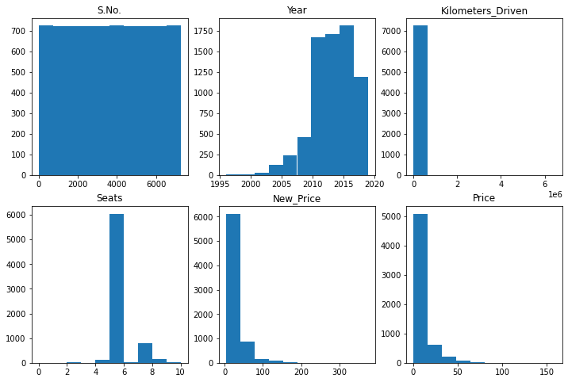

```python
#Create histplots for numerical variables which display utlaiers outside +-1.5*IQR
#NOTE: The technique is same as that presented in content video on Outliers
plt.figure(figsize = (12,8))

for i, variable in enumerate(num_cols):
    plt.subplot(2,3,i+1)
    plt.hist(cars[variable])
    plt.tight_layout
    plt.title(variable)

plt.show()
```

### Observations

- S.No: is a series of numbers 1 to 7253 on a scale of 1. This value will likely be uniformative for the model.
- Year: 50% of the values of Year are integers between 2014 and 2019, inclusively. The data is heavily skewed left with many outliers betweeen 1995 and 2005.
- Kilometers_Driven: Has a max value of 6,500,000. This value is suspect based on domain knowledge of the maximum number of miles that a car can be drive in its lifetime. This value is also an outlier. Likely this value needs to be dropped.
- Seats - Seats appears to be a categorical variable with a mode of 5 (Q1=Median=Q3 = 5);

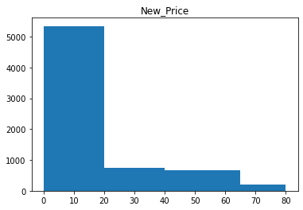

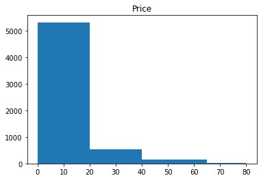

```python
cols_to_bin = ['New_Price', 'Price']
binned_price = [0, 20, 40, 65, 80, np.inf]
for colname in cols_to_bin:
    plt.hist(cars[colname], bins=binned_price)
    plt.title(colname)
    plt.show()
```

## Bivariate Analysis prior to preprocessing

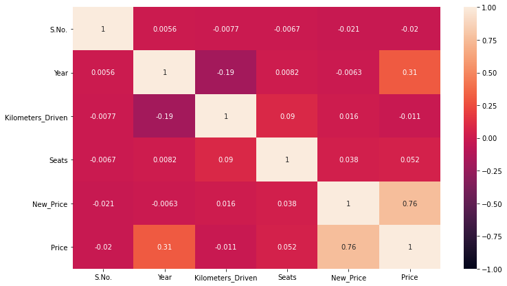

```python
#Corelation Matrix
plt.figure(figsize=(12,7))
sns.heatmap(cars.corr(),annot=True,vmin=-1,vmax=1)
plt.show()
```

### Observations

- Price is positively correlated to Year (0.31)
- New Price is strongly positively correlated to Old Price (0.76)

## Categorical type versus New Price Bivariate Analysis (prior to preprocessing)

```python
cat_cols
```

```
['Location', 'Fuel_Type', 'Transmission', 'Owner_Type', 'Seats']
```

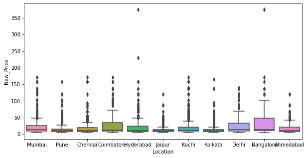

```python
#Locaton Vs New_Price
plt.figure(figsize=(10, 5))
sns.boxplot(x="Location", y="New_Price", data=cars)
plt.show()
```

### Observations

- Location and Price appear to be related
- Some locations, such as Bangladore and Coimbatore appear to have higher "New_Price" variables
- Several other locations such as Pune and Kolkata have lower associate "New_Price"

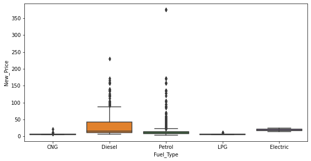

```python
plt.figure(figsize=(10, 5))
sns.boxplot(x="Fuel_Type", y="New_Price", data=cars)
plt.show()
plt.show()
```

### Observations

- From previous observations, CNG, LPG and Electric each account for less than 1% of Cars
- Diesal Cars account for 53% of Cars and are clearly priced more than Petrol cars, which account for 46% of cars

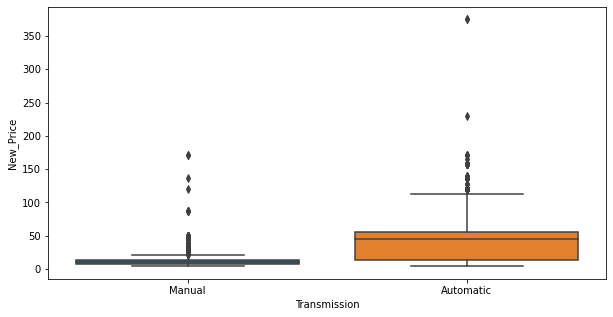

```python
plt.figure(figsize=(10, 5))
sns.boxplot(x="Transmission", y="New_Price", data=cars)
plt.show()
plt.show()
```

### Observations

- 72% of Cars have Manual Transmission. These cars are generally priced lower than cars with Automatic Transission (28% of all cars)

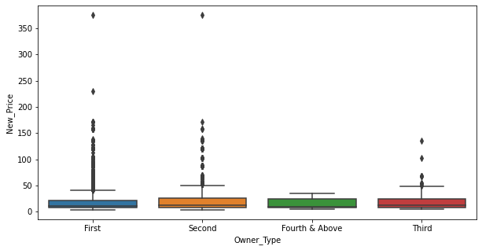

```python
plt.figure(figsize=(10, 5))
sns.boxplot(x="Owner_Type", y="New_Price", data=cars)
plt.show()
plt.show()
```

### Observations

- Owner Type does nto appear to inform New_Price as much as the other categorical variables

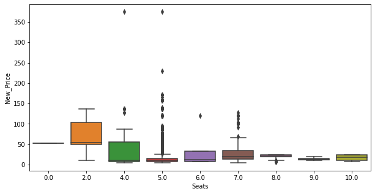

```python
plt.figure(figsize=(10, 5))
sns.boxplot(x="Seats", y="New_Price", data=cars)
plt.show()
plt.show()
```

### Observations

- 84% of Cars have 5 seats, 11% of cars have 7 seats, slightly over 2% of cars have 8 seats and slightly under 2% of cars have 4 seats. The remaining categories of 0(?), 6 seats, 9 seats and 10 seats account for no more than 1% of Cars each.
- 5 seat cars have lower prices that 2 seat cars (most expensive (perhaps sports cars)), 4 seat cars and 7 seat cars.
- 5 seat cars are less expensive in general than cars with other seat counts.

## EDA Summary

### Data Descriptions

- The target variable is Price: dtype is float64
- Although the Name column is object, the data in the name column can be split to Model name and brand name. These columns will be informative for the model.
- Some columns, such as mileage, power and engine are objects but only because they contain the units. Once the units are dropped and the dtype changed to float64, these columns will inform the model.
- The most informative data to predict Price appreaars to be NewPrice.
- S.NO. is not informative for Price.
- Columns such as Location, Seats, Fuel_Type, Owner_Type, Transmission are categorical in nature; once changes to category dtype and then converted to dummy variables, they should inform the model.
- There is a relatively small amount of data which can be imputed so that it is useful.
- Price has some missing data and since it is the target variable, these rows will be dropped to avoid introducing bias to the model.

### Observations

- S. No.: (Seriel Number) appears to have no null values; it is an integer; Seriel number appears to match the row index number; S.No. is a series of numbers 1 to 7253 on a scale of 1. This value will likely be uniformative for the model.
- Name: (Name of car) appears to be categorical yet current data type is object; contains 2 pieces of information (brand name and model name); appears to have no missing values; consider splitting the data and categorizing
- Location: (where the car is being sold) appears to have no missing values; is a object type that posibly should change to category
- Year: (Manufacturing year of car) appears to have no missing values; data type is integer; 50% of the values of Year are integers between 2014 and 2019, inclusively. The data is heavily skewed left with many outliers betweeen 1995 and 2005.
- Kilometers_driven: (total distance drive in kilometers): data type is integer; appears to contain no missing values; Has a max value of 6,500,000. This value is suspect based on domain knowledge of the maximum number of miles that a car can be drive in its lifetime. This value is also an outlier. Likely this value needs to be dropped.
- Fuel_Type: (has the following categories (according to problem statement) Petrol, Diesel, electric, CNG, LPG; appears to contain no missing values; currently dtype object - consider changintto categorical; Diesal Cars account for 53% of Cars and are clearly priced more than Petrol cars, which account for 46% of cars
- Transmission: (either Automatic or Manual) - currently object dtype - consider changing to categorical; appears to contain no missing values
- Owner_Type: Appears to be a cardinal value perhaps representing number of previous owners; appears to contain no missing values; currently an object dtype that might need to be a category; Owner Type does not appear to inform New_Price as much as the other categorical variables
- Millege: (Standard manufacturer declared mileage in km/kg) appears to contain 2 missing values which willneed to imputed or dropped;currently object dtype with units; units will likely be dropped and dtype converted to float
- Engine: (displacement volume of the engine in CC); currently an object dtype containing the units; likely need to drop the units and change the dtype to float; currently contains few missing values
- Power: (max power of he engine in bhp) currently an object dtype containing the units;likely need to drop the units and change the dtype to float; currently contains many missing values
- Seats: (number of seats in car) is currently a float dtype (which might be changes to category); contains few missing; 84% of Cars have 5 seats, 11% of cars have 7 seats, slightly over 2% of cars have 8 seats and slightly under 2% of cars have 4 seats. The remaining categories of 0(?), 6 seats, 9 seats and 10 seats account for no more than 1% of Cars each.5 seat cars have lower prices that 2 seat cars (most expensive (perhaps sports cars)), 4 seat cars and 7 seat cars. 5 seat cars are less expensive in general than cars with other seat counts.
- New_Price: (price of new car/same model in INR Lakhs); apppears to contain no missing values and has dtype of float64 which is appropriate for data;
- Price: (Price of the used car in INR Lakhs): target variable; dtype is float64 which is appropriate; appears to contain many missing values whose corresponding rows will need to dropped

```python
# Copy the dataset before in order to have a dataset on which to perform preprocessing
cars2=cars.copy()
```

```python
cars2.head()
```

|  | S.No. | Name | Location | Year | Kilometers_Driven | Fuel_Type | Transmission | Owner_Type | Mileage | Engine | Power | Seats | New_Price | Price |
| --- | --- | --- | --- | --- | --- | --- | --- | --- | --- | --- | --- | --- | --- | --- |
| 0 | 0 | Maruti Wagon R LXI CNG | Mumbai | 2010 | 72000 | CNG | Manual | First | 26.6 km/kg | 998 CC | 58.16 bhp | 5.0 | 5.51 | 1.75 |
| 1 | 1 | Hyundai Creta 1.6 CRDi SX Option | Pune | 2015 | 41000 | Diesel | Manual | First | 19.67 kmpl | 1582 CC | 126.2 bhp | 5.0 | 16.06 | 12.50 |
| 2 | 2 | Honda Jazz V | Chennai | 2011 | 46000 | Petrol | Manual | First | 18.2 kmpl | 1199 CC | 88.7 bhp | 5.0 | 8.61 | 4.50 |
| 3 | 3 | Maruti Ertiga VDI | Chennai | 2012 | 87000 | Diesel | Manual | First | 20.77 kmpl | 1248 CC | 88.76 bhp | 7.0 | 11.27 | 6.00 |
| 4 | 4 | Audi A4 New 2.0 TDI Multitronic | Coimbatore | 2013 | 40670 | Diesel | Automatic | Second | 15.2 kmpl | 1968 CC | 140.8 bhp | 5.0 | 53.14 | 17.74 |

```python
#Drop the S.No column as it does not inform the model
cars2.drop(columns='S.No.', inplace = True)
```

```python
#Split the Name column into 2 columns;
cars2[['brand_name','model_name']] = cars2['Name'].str.split(' ',1,expand=True)
cars2.head()
```

|  | Name | Location | Year | Kilometers_Driven | Fuel_Type | Transmission | Owner_Type | Mileage | Engine | Power | Seats | New_Price | Price | brand_name | model_name |
| --- | --- | --- | --- | --- | --- | --- | --- | --- | --- | --- | --- | --- | --- | --- | --- |
| 0 | Maruti Wagon R LXI CNG | Mumbai | 2010 | 72000 | CNG | Manual | First | 26.6 km/kg | 998 CC | 58.16 bhp | 5.0 | 5.51 | 1.75 | Maruti | Wagon R LXI CNG |
| 1 | Hyundai Creta 1.6 CRDi SX Option | Pune | 2015 | 41000 | Diesel | Manual | First | 19.67 kmpl | 1582 CC | 126.2 bhp | 5.0 | 16.06 | 12.50 | Hyundai | Creta 1.6 CRDi SX Option |
| 2 | Honda Jazz V | Chennai | 2011 | 46000 | Petrol | Manual | First | 18.2 kmpl | 1199 CC | 88.7 bhp | 5.0 | 8.61 | 4.50 | Honda | Jazz V |
| 3 | Maruti Ertiga VDI | Chennai | 2012 | 87000 | Diesel | Manual | First | 20.77 kmpl | 1248 CC | 88.76 bhp | 7.0 | 11.27 | 6.00 | Maruti | Ertiga VDI |
| 4 | Audi A4 New 2.0 TDI Multitronic | Coimbatore | 2013 | 40670 | Diesel | Automatic | Second | 15.2 kmpl | 1968 CC | 140.8 bhp | 5.0 | 53.14 | 17.74 | Audi | A4 New 2.0 TDI Multitronic |

```python
#Drop the Name Column
cars2.drop(columns='Name', inplace = True)
cars2.info()
```

```
<class 'pandas.core.frame.DataFrame'>
RangeIndex: 7253 entries, 0 to 7252
Data columns (total 14 columns):
 #   Column             Non-Null Count  Dtype
---  ------             --------------  -----
 0   Location           7253 non-null   object
 1   Year               7253 non-null   int64
 2   Kilometers_Driven  7253 non-null   int64
 3   Fuel_Type          7253 non-null   object
 4   Transmission       7253 non-null   object
 5   Owner_Type         7253 non-null   object
 6   Mileage            7251 non-null   object
 7   Engine             7207 non-null   object
 8   Power              7078 non-null   object
 9   Seats              7200 non-null   float64
 10  New_Price          7253 non-null   float64
 11  Price              6019 non-null   float64
 12  brand_name         7253 non-null   object
 13  model_name         7253 non-null   object
dtypes: float64(3), int64(2), object(9)
memory usage: 793.4+ KB
```

```python
cat_vars = ['Location']
for colname in cat_vars:
    cars2[colname] = cars2[colname].astype('category')

cars2.info()
```

```
<class 'pandas.core.frame.DataFrame'>
RangeIndex: 7253 entries, 0 to 7252
Data columns (total 14 columns):
 #   Column             Non-Null Count  Dtype
---  ------             --------------  -----
 0   Location           7253 non-null   category
 1   Year               7253 non-null   int64
 2   Kilometers_Driven  7253 non-null   int64
 3   Fuel_Type          7253 non-null   object
 4   Transmission       7253 non-null   object
 5   Owner_Type         7253 non-null   object
 6   Mileage            7251 non-null   object
 7   Engine             7207 non-null   object
 8   Power              7078 non-null   object
 9   Seats              7200 non-null   float64
 10  New_Price          7253 non-null   float64
 11  Price              6019 non-null   float64
 12  brand_name         7253 non-null   object
 13  model_name         7253 non-null   object
dtypes: category(1), float64(3), int64(2), object(8)
memory usage: 744.2+ KB
```